# Individual3

Shellie Jurchisin

4/12/2021

```r
acc <- read.csv("https://raw.githubusercontent.com/xdaiISU/ds202materials/master/hwlabs/fars2017/accident.csv", stringsAsFactors = FALSE)
```

```r
acc1 <- read.csv("https://raw.githubusercontent.com/xdaiISU/ds202materials/master/hwlabs/fars2017/person.csv", stringsAsFactors = FALSE)
```

#1) Are there some days of the week where more accidents happen than the others (see FARS manual, use variable DAY_WEEK)?

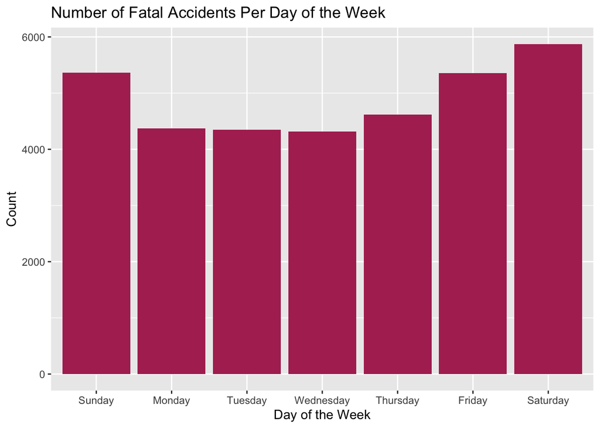

```r
ggplot(acc, aes(x = DAY_WEEK)) + geom_bar(fill = 'maroon') + scale_x_discrete(limit = c('Sunday', 'Monday', 'Tuesday', 'Wednesday', 'Thursday', 'Friday', 'Saturday')) + ggtitle('Number of Fatal Accidents Per Day of the Week') + xlab('Day of the Week') + ylab('Count')
```

#Explanation: From looking at the graph above, it’s apparent that the end of the week has more accidents. Saturday has the most fatal accidents, with a count close to 6,000. During the middle of the week, accidents stay pretty consistent around 4,000, but as the weekend nears, they go up steadily. This pattern makes sense because most of these accidents could be tied to drunk driving, where the weekend is typically when people are more likely to drink, go to the bars, and/or have parties.

#2) Create a data frame containing the persons who are fatally hurt in the accidents (look up variable INJ_SEV)

```r
Fatal <- acc1 %>%
  filter(INJ_SEV == 4) %>%
  select(INJ_SEV)
head(Fatal)
```

```
##   INJ_SEV
## 1       4
## 2       4
## 3       4
## 4       4
## 5       4
## 6       4
```

#3) Create a data frame containing the most dangerous vehicle make in each state. The number of persons fatally hit in the vehicle make is used to assess the (non-)safety of a make. Make sure to handle the missing values appropriately. (look up variable MAKE)

```r
DangerousVehicle <- acc1 %>%
  group_by(STATE, MAKE) %>%
  summarize(nFatal = n())
DangerousVehicle
```

```
## # A tibble: 2,324 x 3
## # Groups:   STATE [51]
##    STATE  MAKE nFatal
##    <int> <int>  <int>
##  1     1     2     61
##  2     1     3      4
##  3     1     6     32
##  4     1     7    116
##  5     1     9      4
##  6     1    12    270
##  7     1    13     13
##  8     1    14     29
##  9     1    18     31
## 10     1    19     19
## # … with 2,314 more rows
```

```r
MostDangerous <- DangerousVehicle %>%
  group_by(STATE) %>%
  filter(nFatal == max(nFatal))
MostDangerous
```

```
## # A tibble: 52 x 3
## # Groups:   STATE [51]
##    STATE  MAKE nFatal
##    <int> <int>  <int>
##  1     1    20    293
##  2     2    20     29
##  3     4    12    305
##  4     5    20    171
##  5     6    49   1079
##  6     8    12    176
##  7     9    37     63
##  8    10    NA     40
##  9    11    37     13
## 10    11    NA     13
## # … with 42 more rows
```

```r
MostDangerous1 <- na.omit(MostDangerous)
MostDangerous1
```

```
## # A tibble: 44 x 3
## # Groups:   STATE [44]
##    STATE  MAKE nFatal
##    <int> <int>  <int>
##  1     1    20    293
##  2     2    20     29
##  3     4    12    305
##  4     5    20    171
##  5     6    49   1079
##  6     8    12    176
##  7     9    37     63
##  8    11    37     13
##  9    12    12    930
## 10    13    12    608
## # … with 34 more rows
```

#4) Create a map, and label each state with the most dangerous vehicle. Discuss the definition of the most dangerous vehicle, and what you find from the map. (Hint: Read the description for the STATE and COUNTY columns in the FARS manual. The state & county codes are Geographic Locator Codes (GLCs) from the General Services Administration’s (GSA) publication. Use readxl::read_xlsx to read in the GLCs.)

```r
StateCounty <- readxl::read_xlsx('FRPP_GLC_-_United_StATESaPRIL62021.xlsx')
StateCounty
```

```
## # A tibble: 39,738 x 11
##    Territory `State Name` `State Code` `City Code` `City Name` `County Code`
##    <chr>     <chr>        <chr>        <chr>       <chr>       <chr>
##  1 U         ALABAMA      1            10          ABBEVILLE   67
##  2 U         ALABAMA      1            50          ALBERTVILLE 95
##  3 U         ALABAMA      1            60          ALEXANDER … 123
##  4 U         ALABAMA      01           0070        ALICEVILLE  107
##  5 U         ALABAMA      1            90          ANDALUSIA   39
##  6 U         ALABAMA      1            96          ANDERSON    77
##  7 U         ALABAMA      1            100         ANNISTON    15
##  8 U         ALABAMA      1            101         ANNISTON A… 15
##  9 U         ALABAMA      1            103         ANSLEY      109
## 10 U         ALABAMA      1            110         ARAB        95
## # … with 39,728 more rows, and 5 more variables: `County Name` <chr>, `Country
## #   Code` <chr>, `Old City Name` <chr>, `Date Record Added` <lgl>, `Duty
## #   Station Code` <chr>
```

```r
str(StateCounty)
```

```
## tibble [39,738 × 11] (S3: tbl_df/tbl/data.frame)
##  $ Territory        : chr [1:39738] "U" "U" "U" "U" ...
##  $ State Name       : chr [1:39738] "ALABAMA" "ALABAMA" "ALABAMA" "ALABAMA" ...
##  $ State Code       : chr [1:39738] "1" "1" "1" "01" ...
##  $ City Code        : chr [1:39738] "10" "50" "60" "0070" ...
##  $ City Name        : chr [1:39738] "ABBEVILLE" "ALBERTVILLE" "ALEXANDER CITY" "ALICEVILLE" ...
##  $ County Code      : chr [1:39738] "67" "95" "123" "107" ...
##  $ County Name      : chr [1:39738] "HENRY" "MARSHALL" "TALLAPOOSA" "PICKENS" ...
##  $ Country Code     : chr [1:39738] "840" "840" "840" "840" ...
##  $ Old City Name    : chr [1:39738] NA NA NA NA ...
##  $ Date Record Added: logi [1:39738] NA NA NA NA NA NA ...
##  $ Duty Station Code: chr [1:39738] "010010067" "010050095" "010060123" "010070107" ...
```

```r
states = map_data("state")
str(states)
```

```
## 'data.frame':    15537 obs. of  6 variables:
##  $ long     : num  -87.5 -87.5 -87.5 -87.5 -87.6 ...
##  $ lat      : num  30.4 30.4 30.4 30.3 30.3 ...
##  $ group    : num  1 1 1 1 1 1 1 1 1 1 ...
##  $ order    : int  1 2 3 4 5 6 7 8 9 10 ...
##  $ region   : chr  "alabama" "alabama" "alabama" "alabama" ...
##  $ subregion: chr  NA NA NA NA ...
```

```r
justStates <- StateCounty %>%
  distinct(`State Code`, `State Name`)
justStates
```

```
## # A tibble: 52 x 2
##    `State Name`         `State Code`
##    <chr>                <chr>
##  1 ALABAMA              1
##  2 ALABAMA              01
##  3 ALASKA               2
##  4 ARIZONA              4
##  5 ARKANSAS             5
##  6 CALIFORNIA           6
##  7 COLORADO             8
##  8 CONNECTICUT          9
##  9 DELAWARE             10
## 10 DISTRICT OF COLUMBIA 11
## # … with 42 more rows
```

```r
MostDangerous2 <- MostDangerous1 %>%
  mutate(STATE = as.character(STATE)) %>%
  inner_join(justStates, by = c('STATE' = "State Code"))
MostDangerous2
```

```
## # A tibble: 44 x 4
## # Groups:   STATE [44]
##    STATE  MAKE nFatal `State Name`
##    <chr> <int>  <int> <chr>
##  1 1        20    293 ALABAMA
##  2 2        20     29 ALASKA
##  3 4        12    305 ARIZONA
##  4 5        20    171 ARKANSAS
##  5 6        49   1079 CALIFORNIA
##  6 8        12    176 COLORADO
##  7 9        37     63 CONNECTICUT
##  8 11       37     13 DISTRICT OF COLUMBIA
##  9 12       12    930 FLORIDA
## 10 13       12    608 GEORGIA
## # … with 34 more rows
```

```r
states1 <- states %>%
  select(long, lat, region)
head(states1)
```

```
##        long      lat  region
## 1 -87.46201 30.38968 alabama
## 2 -87.48493 30.37249 alabama
## 3 -87.52503 30.37249 alabama
## 4 -87.53076 30.33239 alabama
## 5 -87.57087 30.32665 alabama
## 6 -87.58806 30.32665 alabama
```

```r
MostDangerous3 <- MostDangerous2 %>%
  select(`State Name`, MAKE)
MostDangerous3
```

```
## # A tibble: 44 x 3
## # Groups:   STATE [44]
##    STATE `State Name`          MAKE
##    <chr> <chr>                <int>
##  1 1     ALABAMA                 20
##  2 2     ALASKA                  20
##  3 4     ARIZONA                 12
##  4 5     ARKANSAS                20
##  5 6     CALIFORNIA              49
##  6 8     COLORADO                12
##  7 9     CONNECTICUT             37
##  8 11    DISTRICT OF COLUMBIA    37
##  9 12    FLORIDA                 12
## 10 13    GEORGIA                 12
## # … with 34 more rows
```

```r
states1$region <- toupper(states1$region)

StateLonLat <- MostDangerous3 %>%
  group_by(`State Name`, MAKE) %>%
  right_join(states1, by = c('State Name' = 'region')) %>%
  summarize(long = mean(long),
            lat = mean(lat)) %>%
  na.omit(MAKE)
StateLonLat
```

```
## # A tibble: 42 x 4
## # Groups:   State Name [42]
##    `State Name`          MAKE   long   lat
##    <chr>                <int>  <dbl> <dbl>
##  1 ALABAMA                 20  -86.9  31.7
##  2 ARIZONA                 12 -113.   34.5
##  3 ARKANSAS                20  -91.3  34.6
##  4 CALIFORNIA              49 -121.   36.7
##  5 COLORADO                12 -105.   38.6
##  6 CONNECTICUT             37  -72.7  41.4
##  7 DISTRICT OF COLUMBIA    37  -77.1  38.9
##  8 FLORIDA                 12  -83.4  28.7
##  9 GEORGIA                 12  -82.6  32.2
## 10 IDAHO                   12 -115.   45.5
## # … with 32 more rows
```

```r
StateLonLat1 <- StateLonLat %>%
  ungroup() %>%
  select(MAKE, long, lat)
StateLonLat1
```

```
## # A tibble: 42 x 3
##     MAKE   long   lat
##    <int>  <dbl> <dbl>
##  1    20  -86.9  31.7
##  2    12 -113.   34.5
##  3    20  -91.3  34.6
##  4    49 -121.   36.7
##  5    12 -105.   38.6
##  6    37  -72.7  41.4
##  7    37  -77.1  38.9
##  8    12  -83.4  28.7
##  9    12  -82.6  32.2
## 10    12 -115.   45.5
## # … with 32 more rows
```

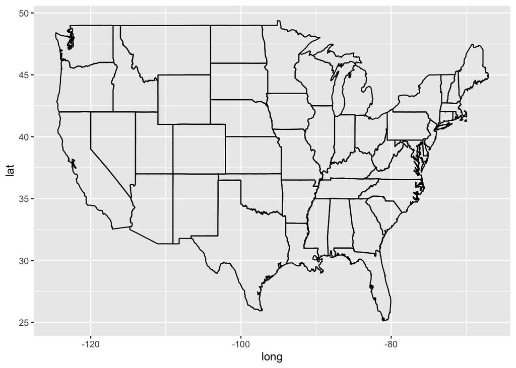

```r
ggplot(states, aes(x = long, y = lat)) + geom_path(aes(group=group))
```

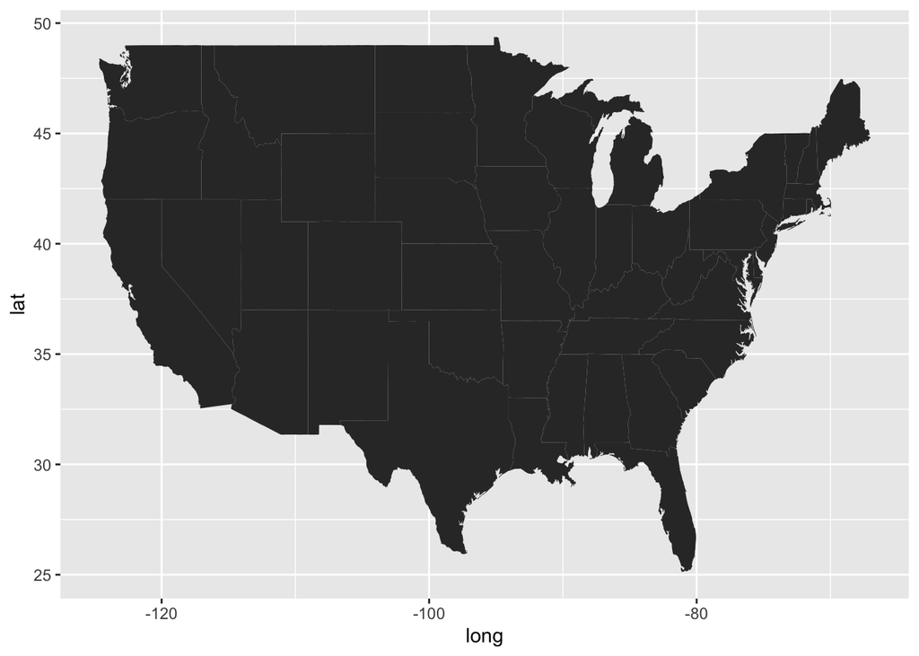

```r
ggplot(states, aes(x = long, y = lat)) + geom_polygon(aes(group=group))
```

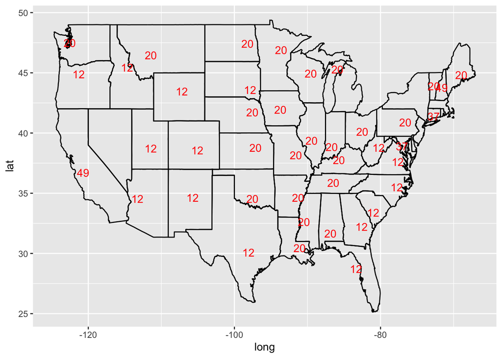

```r
ggplot(states, aes(x = long, y = lat)) + geom_path(aes(group=group)) + geom_text(aes(label = MAKE), color = 'red', data = StateLonLat1)
```

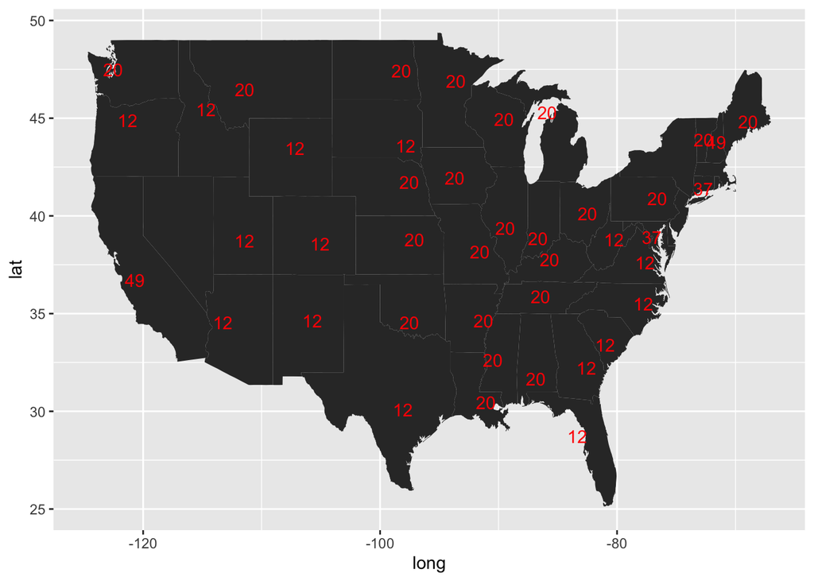

```r
ggplot(states, aes(x = long, y = lat)) + geom_polygon(aes(group=group)) + geom_text(aes(label = MAKE), color = 'red', data = StateLonLat1)
```

#5) Join the accident and person table (work out which variable(s) to use)

```r
joinedtables <- left_join(acc, acc1)
head(joinedtables)
```

```
##   STATE ST_CASE VE_TOTAL VE_FORMS PVH_INVL PEDS PERNOTMVIT PERMVIT PERSONS
## 1     1   10001        1        1        0    0          0       1       1
## 2     1   10002        1        1        0    0          0       1       1
## 3     1   10003        3        3        0    0          0       3       3
## 4     1   10003        3        3        0    0          0       3       3
## 5     1   10003        3        3        0    0          0       3       3
## 6     1   10004        1        1        0    0          0       1       1
##   COUNTY CITY DAY MONTH YEAR DAY_WEEK HOUR MINUTE NHS RUR_URB FUNC_SYS RD_OWNER
## 1     73  330  19     2 2017        1   23     35   1       2        1        1
## 2     89 1730  14     2 2017        3   14     59   1       2        1        1
## 3    101 2130  31     1 2017        3   20     31   1       2        1        1
## 4    101 2130  31     1 2017        3   20     31   1       2        1        1
## 5    101 2130  31     1 2017        3   20     31   1       2        1        1
## 6     73  350   1     1 2017        1   16     55   0       2        4        4
##   ROUTE        TWAY_ID       TWAY_ID2 MILEPT LATITUDE  LONGITUD SP_JUR HARM_EV
```

[output cut: 69 more lines]

#6) Tally the number of accidents by day of the week (DAY_WEEK), hour of the day (HOUR) and gender (SEX). Visualize the results and explain what you find.

```r
joinedtables$HOUR <- as.integer(joinedtables$HOUR)
joinedtables2 <- joinedtables %>%
  filter(HOUR != "99" & SEX <=3) %>%
  mutate(Sex = if_else(SEX == 1, 'Male', 'Female')) %>%
  group_by(HOUR, DAY_WEEK, Sex) %>%
  summarize(ACCIDENTS = n()) %>%
  mutate(SEX = as.factor(Sex))
```

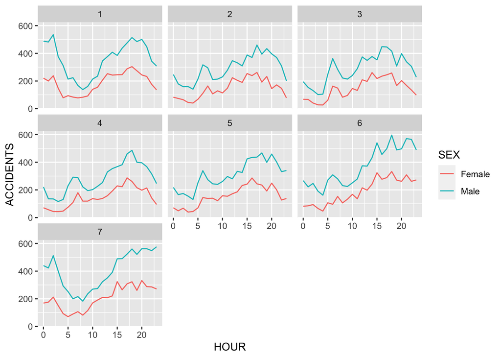

```r
joinedtables2$Weekday <- wday(joinedtables2$DAY_WEEK, label = T)

ggplot(joinedtables2, aes(x = HOUR, y = ACCIDENTS, color = SEX)) + geom_line() + facet_wrap(~DAY_WEEK)
```

#Explanation: From the graphs we can observe that males get into more accidents than females overall. However, both males and females follow a similar pattern of rises and declines in accidents throughout each week day. Males and females tend to get into the most accidents around midnight on Sunday (day 1) and the late afternoon-evening on every day of the week. Friday (day 6) and Saturday (day 7) see the highest peaks in accidents among the other days, and this peak is in the late evening. Saturday, as well as Sunday, also see high accident peaks just after midnight. The fact that Friday, Saturday and Sunday show the highest peaks in accidents makes sense because people are more likely to go out to drink on these days and drunk drive afterward.

#7 - Now plot a choropleth map of the number of deaths on a county level. Also explain what you find.

```r
StateCounty$'State Code' <- as.numeric(StateCounty$'State Code')
StateCounty$'City Code' <- as.numeric(StateCounty$'City Code')
StateCounty$'County Code' <- as.numeric(StateCounty$'County Code')

counties = map_data("county")
str(counties)
```

```
## 'data.frame':    87949 obs. of  6 variables:
##  $ long     : num  -86.5 -86.5 -86.5 -86.6 -86.6 ...
##  $ lat      : num  32.3 32.4 32.4 32.4 32.4 ...
##  $ group    : num  1 1 1 1 1 1 1 1 1 1 ...
##  $ order    : int  1 2 3 4 5 6 7 8 9 10 ...
##  $ region   : chr  "alabama" "alabama" "alabama" "alabama" ...
##  $ subregion: chr  "autauga" "autauga" "autauga" "autauga" ...
```

```r
StatesandCounties <- StateCounty %>%
  distinct(`State Code`, `State Name`, `County Code`, `County Name`)
StatesandCounties
```

```
## # A tibble: 3,150 x 4
##    `State Name` `State Code` `County Code` `County Name`
##    <chr>               <dbl>         <dbl> <chr>
##  1 ALABAMA                 1            67 HENRY
##  2 ALABAMA                 1            95 MARSHALL
##  3 ALABAMA                 1           123 TALLAPOOSA
##  4 ALABAMA                 1           107 PICKENS
##  5 ALABAMA                 1            39 COVINGTON
##  6 ALABAMA                 1            77 LAUDERDALE
##  7 ALABAMA                 1            15 CALHOUN
##  8 ALABAMA                 1           109 PIKE
##  9 ALABAMA                 1            83 LIMESTONE
## 10 ALABAMA                 1            73 JEFFERSON
## # … with 3,140 more rows
```

```r
fatalStCount <- acc1 %>%
  group_by(STATE, COUNTY) %>%
  summarize(nFatal = n())
fatalStCount
```

```
## # A tibble: 2,840 x 3
## # Groups:   STATE [51]
##    STATE COUNTY nFatal
##    <int>  <int>  <int>
##  1     1      1     35
##  2     1      3     44
##  3     1      5     12
##  4     1      7     16
##  5     1      9     48
##  6     1     11     11
##  7     1     13     34
##  8     1     15     55
##  9     1     17      6
## 10     1     19     15
## # … with 2,830 more rows
```

```r
fatalStCount2 <- fatalStCount %>%
  group_by(nFatal) %>%
  right_join(StatesandCounties, by = c('STATE' = 'State Code', 'COUNTY' = 'County Code'))
fatalStCount2
```

```
## # A tibble: 3,150 x 5
## # Groups:   nFatal [200]
##    STATE COUNTY nFatal `State Name` `County Name`
##    <dbl>  <dbl>  <int> <chr>        <chr>
##  1     1      1     35 ALABAMA      AUTAUGA
##  2     1      3     44 ALABAMA      BALDWIN
##  3     1      5     12 ALABAMA      BARBOUR
##  4     1      7     16 ALABAMA      BIBB
##  5     1      9     48 ALABAMA      BLOUNT
##  6     1     11     11 ALABAMA      BULLOCK
##  7     1     13     34 ALABAMA      BUTLER
##  8     1     15     55 ALABAMA      CALHOUN
##  9     1     17      6 ALABAMA      CHAMBERS
## 10     1     19     15 ALABAMA      CHEROKEE
## # … with 3,140 more rows
```

```r
counties$region <- toupper(counties$region)
counties$subregion <- toupper(counties$subregion)

fatalStCount3 <- fatalStCount2 %>%
  left_join(counties, by = c('State Name' = 'region', 'County Name' = 'subregion'))
fatalStCount3
```

```
## # A tibble: 86,893 x 9
## # Groups:   nFatal [200]
##    STATE COUNTY nFatal `State Name` `County Name`  long   lat group order
##    <dbl>  <dbl>  <int> <chr>        <chr>         <dbl> <dbl> <dbl> <int>
##  1     1      1     35 ALABAMA      AUTAUGA       -86.5  32.3     1     1
##  2     1      1     35 ALABAMA      AUTAUGA       -86.5  32.4     1     2
##  3     1      1     35 ALABAMA      AUTAUGA       -86.5  32.4     1     3
##  4     1      1     35 ALABAMA      AUTAUGA       -86.6  32.4     1     4
##  5     1      1     35 ALABAMA      AUTAUGA       -86.6  32.4     1     5
##  6     1      1     35 ALABAMA      AUTAUGA       -86.6  32.4     1     6
##  7     1      1     35 ALABAMA      AUTAUGA       -86.6  32.4     1     7
##  8     1      1     35 ALABAMA      AUTAUGA       -86.6  32.4     1     8
##  9     1      1     35 ALABAMA      AUTAUGA       -86.6  32.4     1     9
## 10     1      1     35 ALABAMA      AUTAUGA       -86.6  32.4     1    10
## # … with 86,883 more rows
```

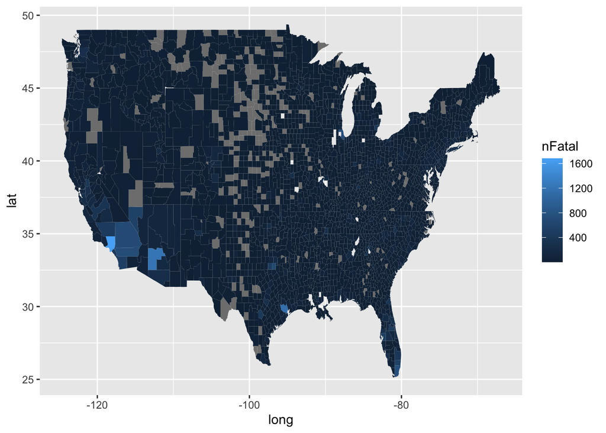

```r
fatalStCount3 %>%
  ggplot(aes(x = long, y = lat)) + geom_polygon(aes(group = group, fill = nFatal))
```

#8) Is summer or winter more dangerous? Does this depend on states? Explore and explain.

```r
joinedtables$MONTH <- as.integer(joinedtables$MONTH)
joinedtables3 <- joinedtables %>%
  filter(MONTH != c(3, 4, 5, 9, 10) & INJ_SEV >=4) %>%
  mutate(MONTH = ifelse(MONTH == c(6, 7, 8), 'Summer', 'Winter')) %>%
  group_by(MONTH, INJ_SEV) %>%
  summarize(ACCIDENTS = n()) %>%
  mutate(MONTH = as.factor(MONTH))
```

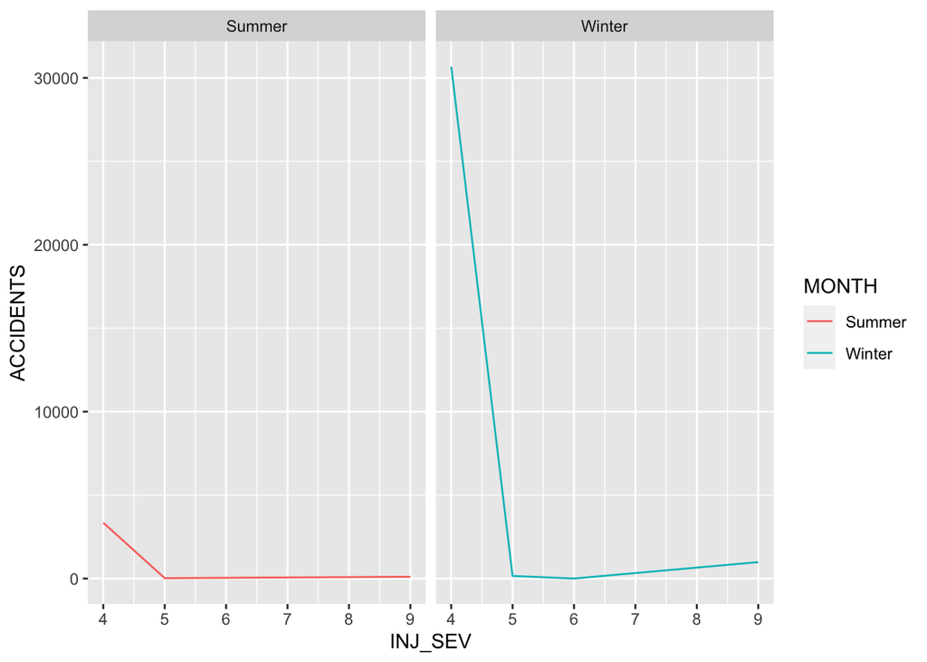

```r
ggplot(joinedtables3, aes(x = INJ_SEV, y = ACCIDENTS, color = MONTH)) + geom_line() + facet_wrap(~MONTH)
```